# Automating Writing from Amanuenses to AI

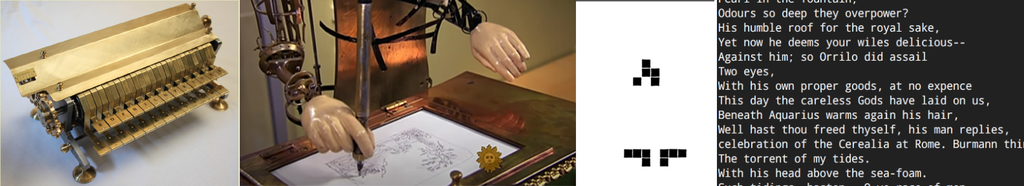

ENGLIT 2122 Fall 2021, Mondays 2-450pm ET, 501 CL University of Pittsburgh Prof. Annette Vee Office hour: Thurs 1-2pm bit.ly/meetannetteonline (or in my physical office 628C CL) Or happily by appointment!

*Sponsored by a grant from the [Humanities Engage Summer Stipend for Curricular Innovation](https://www.humanitiescareers.pitt.edu/faculty-summer-stipends-curricular-innovation). This course counts towards the [Digital Studies and Methods certificate](https://www.dsam.pitt.edu/) and the [Composition Certificate](https://www.composition.pitt.edu/graduate/certificate).*

## Course Description

We swim in a sea of writing, much of it written by algorithms rather than humans. Automated Writing Systems (AWS) that employ natural language processing techniques are currently used to amplify political messages on social media, to convey sports and financial statistics, to generate click-worthy headlines, as smartphone chatbots, and as creative writing aids. Automated essay scoring, search engine optimization, machine translation, and text processing techniques determine educational outcomes, popularity of websites, or help us to analyze unique features of documents or massive archives. Whether or not we use them ourselves, AWS are shaping the circulation of our writing and the environment in which we read.

The ability to use complex and sequential language, such as writing demonstrates, is an exclusively human activity. Yet people have pursued ways of automating this human capability for centuries–from mechanized automatons in the 18th century to twitterbots in the 21st. Language is an infinite system, but the translation of language into writing—especially print—discretizes it, suggesting that it may be possible to fully automate. English has 26 letters, spaces and punctuation: how hard could it be to write a system that uses those discrete inputs and writes for us?

Very hard, actually. Using massive datasets and parameters, contemporary AWS like GPT-3 produce passable prose. The comprehension rate for AWS-produced text jumps considerably as the genre narrows: earthquake and sport reports are solved problems. But bypassing the question of can we automate writing? (not really), let’s ask instead: why would we want to automate writing? What does it say about humans that we keep banging our heads on this mechanical, computational, philosophical problem of language?

Automating Writing is a historical and technical dive into why people have developed automated writing systems (AWS), what challenges AWS offer, and how to implement AWS using natural language processing and public data sets. The course brings gendered and racialized histories of office automation and amanuenses for the writing-down of narratives from enslaved people in conversation with contemporary questions in artificial intelligence such as whose intelligence is being simulated and how. We will explore: what writing is; power dynamics in writing; the limits of what computers can do; and the relationship of human consciousness to computation. Hands-on work in AWS-related systems include basic programming; [Tracery](https://tracery.io/) (using Javascript) and [InferKit](https://inferkit.com/) (using GPT-2); Twitterbots; [Conway’s game of life](https://en.wikipedia.org/wiki/Conway%27s_Game_of_Life); the [Leibniz cipher machine](https://pitt.libguides.com/leibniz) held by Pitt ULS. Assignments include reading histories of AWS, writing short blog posts analyzing different historical and contemporary AWS or their products, and playing with algorithms and datasets such as GPT-2 (an AWS that uses machine learning and which is publicly available in a scaled-down version). The final project for the course asks you to break the boundaries of the class: develop a unit to teach something you learned here in Pitt undergrad English courses like Composing Digital Media or Narrative and Technology; an online creative project using automated writing; a public art project; a workshop you run for others and document; or another relevant project of your choice. Through readings on algorithms and historical studies of writing automata such as the [Maillardet Automaton](https://www.fi.edu/history-resources/automaton), alongside learning how to use an AWS such as GPT-2, students will get both a theoretical and practical introduction to automated writing systems, contemporary writing and machine learning.

## Learning goals

Students completing this course can expect to: - 1. Consider questions of human identity and existence vis a vis the automata humans create for writing - 2. Name several historical automata and their significance for their contemporary engineering, mathematical, scientific and philosophical contexts - 3. Experience systems related to AWS that are mechanical or computational - 4. Understand how machine learning in textual processing systems such as GPT-2 works using massive datasets and training on specific texts - 5. Produce automated writing using systems such as Tracery or GPT-2 - 6. Translate automated writing systems into a public instantiation

## Assessment

30% participation in class discussion (including “deep reading” days) 40% course blog writings and weekly exercises 30% final project

Because this is a grad course, this breakdown should be considered a rough guide rather than a mathematical certainty. Please talk with me if you have questions or concerns.

## Course Responsibilities

### Blog writings and deep reading weeks

Please choose four weeks that look particularly interesting to you. Choose two of these weeks to write a ~500 word blog post on the readings, activities, or anything else connected to the theme of the week. For the other two weeks, you will read deeply. That is, you will ensure that you are a relative expert on the texts for the week; you will have interesting questions to pose to your peers; you will have thought about connections between texts, etc. You do not have to lead discussion for these weeks, but we will assume you’ll be an especially active participant in it. The class will sign up for these weeks at the beginning of the term.

### Final project

Your final project will take the practices or ideas of automated writing that you’ve wrestled with in the class out into the world in some way. Some possibilities: a community workshop or lesson plan for a K-12 setting, plus a reflection on this design; a textual public art installation and reflection; a research article that is on a path to journal submission; a website that includes multiple small texts or images or interactions related to automated writing. The format is flexible and later in the term, we will discuss what might work for your specific interests and goals.

UPDATE: The Final Project submission portal is now (as of 12/6) open on Canvas. You are welcome to turn in your final project anytime during Finals Week, Dec 13-17. I have met with you all individually about your project plans. Please keep in touch as it takes shape to make sure that we’re on the same page with it. You will be sharing your project in some form during our final day of class, 12/13.

## Course Policies and Resources

### Mutual respect

This course draws students from multiple disciplines. We all bring to the course a particular constellation of personal, experiential, academic and professional expertise. Together, can create an open classroom and the sharing of ideas in a safe, respectful environment. In order to facilitate this open exchange of ideas, as members of this class, we agree that we will not engage in derogatory language, writing, or expressions against race, ethnicity, religion, gender identification, sexuality, economic position, and political views. Any disagreement in class discussion with me or with your fellow students should be respectfully expressed.

### Course format

The format of this course will follow the policies of University of Pittsburgh. Please check https://www.coronavirus.pitt.edu/ for policies. We will begin meeting in person and I will communicate any change in format over email.

### Late work

It’s better for everyone when you get work in on time: it helps you stay on track; helps you participate in discussion of the work among ourselves; and helps me to manage our teaching responsibilities to you. But stuff happens. Please get in touch if you are encountering a significant challenge to completing your work. Better late than never, and better late than compromised.

### Absences

Please let me know ahead of time if you will need to be absent from class. I will let you know how you might make up work for the class. Make-up activities do not fully substitute for attendance, but will help you to stay connected to the themes and ideas of the course. Because this is a seminar, more than one absence may affect your participation grade.

### Statement on Academic Integrity

This is a collaborative class, in which we offer each other suggestions and constructive criticism. However, the goal of all this collaboration is to clarify the expression of original ideas – never to substitute someone else’s ideas for our own, or to impose our ideas on someone else. If you have any questions, don’t hesitate to ask, because Pitt takes a very hard stance on plagiarism. Here’s an excerpt from the official Policy on Academic Integrity (required for Pitt syllabi):

> Cheating/plagiarism will not be tolerated. Students suspected of violating the University of Pittsburgh Policy on Academic Integrity, from the February 1974 Senate Committee on Tenure and Academic Freedom reported to the Senate Council, will be required to participate in the outlined procedural process as initiated by the instructor. A minimum sanction of a zero score for the quiz or exam will be imposed.

You have the right to a fair hearing, and I’ll talk to you before we talk to anyone else, but it’s far easier just to avoid plagiarism in the first place. All clear cases of deliberate plagiarism will be referred to the appropriate Dean for disciplinary action, including an Academic Integrity Board hearing. View more on Pitt’s policy on the [Provost’s website](http://www.provost.pitt.edu/faculty/academic-integrity-freedom/academic-integrity-guidelines).

### Policy on Children in Class

Children are welcome in this class when your role as a caregiver overlaps with your role as a student. If a child is sick, please do not bring them to class–instead, please contact me directly about alternative arrangements such as videoconferencing. While this is not meant to be a long-term childcare solution, occasionally bringing a child to class in order to cover gaps in care is perfectly acceptable. I ask that you sit close to the door so that if your little one needs special attention and is disrupting learning for other students, you may step outside until their need has been met. If you have any other parenting needs, please feel free to approach me so that we can work together towards a solution. While we maintain the same high expectations for all students regardless of parenting status, we are happy to problem solve with you in a way that makes you feel supported as you strive for school-parenting balance.

### Inclusivity Policy (Disability Resources)

Your success in this class is important to us. I recognize that everyone learns differently. Although I have designed the course to tap into different learning styles (online participation, f2f participation, videos, text, etc.), I recognize that everyone will find different aspects of the course challenging. Challenge is good! But if there are aspects of this course that prevent you from learning or exclude you, please let me know as soon as possible. Together we’ll develop strategies to meet both your needs and the requirements of the course. If you need official accommodations, you have a right to have these met.

If you require accommodation for a disability, please inform us and the [Office of Disability Resources and Services](https://www.diversity.pitt.edu/disability-access/disability-resources-and-services) as early as possible in the term. You can reach DRS at (412) 648-7890 or (412) 383-7355 and you can visit their office at 216 William Pitt Union.

I encourage you to visit me in office hours (see above) to determine how you could improve your learning as well.

### Support Resources

There are also a range of resources on campus to support your life as a student, including [the Writing Center](https://www.writingcenter.pitt.edu/) and the [Counseling Center](https://www.studentaffairs.pitt.edu/cc/). Pitt Libraries has put together an amazing and comprehesive list of housing assistance, food assistance, etc etc.: https://pitt.libguides.com/assistanceresources/home

### Names and Pronouns Policy

As a graduate instructor, I go by my first name, Annette. Feel free to address me by my first name. I use she/her/hers pronouns. If you have preferences about pronouns and naming for the class, please let us know and we will respect your wishes. I also request that you respect the wishes of our classroom community.

### Email Communication Policy

If you do not ordinarily use your Pitt email address, please make sure that the Pitt address is forwarding properly to whatever email address you do use, since I will be sending messages this way. I expect that you will read your email regularly and may communicate about any course changes via email. The University provides an email forwarding service that allows students to read their email via other service providers (e.g. Google, Yahoo), but you do so at your own risk. To forward email sent to your University account, go to http://accounts.pitt.edu, log into your account, click on Edit Forwarding Addresses, and follow the instructions on the page. Be sure to logout of your account when you have finished. (full [email Communication Policy](https://www.policy.pitt.edu/ao-15-e-mail-communication-policy-formerly-09-10-01))

Before emailing me a question about the course, please check the syllabus to see if your answer is here. I will attempt to answer your emails about the course promptly.

## Schedule and Texts

Each week of this course we’ll explore another facet of automated writing. As with most graduate classes, there is too much to contend with each week. I’ve listed the texts in order of my own priorities for the class. Yours may be different, and your time available each week will fluctuate. I ask that you do your best to contend with as much of the material as possible each week in order to be prepared for the week’s discussion.

You are not *required* to purchase any books for this course; all readings and texts are available online or through PittCat or will be excerpted and made available in Canvas. I *recommend* that you purchase two books or find a partner in the class to share with: * Bertram, Lillian-Yvonne. Travesty Generator. http://www.noemipress.org/catalog/poetry/travesty-generator/ * Shane, Janelle. You Look Like a Thing and I Love You. Voracious, 2019. (On one day reserve at Hillman Library; visit the information desk to pick it up, and check PittCat for availability.)

### 1. Overview of contemporary automating writing 8/30/21

Bender, Gebru, McMillan-Major, Mitchell. “On the Dangers of Stochastic Parrots: Can Language Models Be Too Big?” FAccT ’21: Proceedings of the 2021 ACM Conference on Fairness, Accountability, and Transparency. March 2021. 610–623. https://doi.org/10.1145/3442188.3445922 [open access] This paper was at the center of Gebru and Mitchell’s firings from Google. See this story for context: https://www.wired.com/story/google-timnit-gebru-ai-what-really-happened

Seabrook, John. “Can a Machine Learn to Write for the New Yorker?” The New Yorker. 14 Oct 2019. https://www.newyorker.com/magazine/2019/10/14/can-a-machine-learn-to-write-for-the-new-yorker

Fagone, Jason. “The Jessica Simulation: Love and Loss in the Age of AI.” San Francisco Chronicle. 23 July 2021. https://www.sfchronicle.com/projects/2021/jessica-simulation-artificial-intelligence/

Vara, Vauhini. “Ghosts” Believer. 9 August 2021. https://believermag.com/ghosts/

**In class:** Montfort, Nick. “Christopher Strachey, The First Digital Artist?” Grand Text Auto [blog], 1 August 2005. https://grandtextauto.soe.ucsc.edu/2005/08/01/christopher-strachey-first-digital-artist/

Play with an online demo of Christopher Strachey’s Love Letter Generator

**Optional:** Extra stuff/updates on Project December: https://www.komando.com/episode/she-passed-away-then-he-turned-her-into-an-ai-chatbot/802949/ Jason Rohrer project December tweets (collected Aug-Sept 2021, in files on Canvas)

### 2. No class on Labor Day 9/6/21

Note that add/drop deadline is 9/10/21

Watch this lecture I gave last fall to Big Ideas in Computing, Artificial Writing and Intelligence https://pitt.hosted.panopto.com/Panopto/Pages/Viewer.aspx?id=30e090f1-9bab-42e7-b1aa-acd20183199f (transcript available there) https://docs.google.com/presentation/d/1qibA1L8sd15oyQ12-hzsr_n2ZpiOS4z9rW-o4Daw_bc/edit?usp=sharing (slides to follow along, with notes) Explore autocomplete in your email or phone, e.g., https://blog.google/products/search/how-google-autocomplete-works-search/ Look out for other instances of automated writing systems in your life and research and bring something to share for next week.

### 3. Why do we automate writing? 9/13/21

Crosthwaite, Paul. “Clockwork Automata, Artificial Intelligence and Why the Body of the Author Matters.” Minds, Bodies, Machines, 1770–1930, edited by Deirdre Coleman and Hilary Fraser, Palgrave Macmillan, 2011, pp. 83–104, https://canvas.pitt.edu/courses/125417/files

Booten, Kyle and Dan Rockmore, “The Anxiety of Imitation: On the “Boringness” of Creative Turing Tests,” electronic book review, 3 May 2020. https://electronicbookreview.com/essay/the-anxiety-of-imitation-on-the-boringness-of-creative-turing-tests/

Bertram, Lillian-Yvonne. Travesty Generator. http://www.noemipress.org/catalog/poetry/travesty-generator/ [book of poetry using computational methods] Watch beginning at 22:20 (about 30min) https://www.crowdcast.io/e/soundsxcaapp/1 (you’re welcome to watch the whole thing!) Related info shared in class: https://medium.com/sfpc/code-words-day-4-with-lillian-yvonne-bertram-83592e791c33 Zach Whalen review: http://wg20.criticalcodestudies.com/index.php?p=/discussion/99/code-critique-book-review-travesty-generator-by-lillian-yvonne-bertram http://www.in-vacua.com/tapemark_code.txt

In class: * Write: Why automate writing? and what other key questions/themes are you interested in today? * Discuss: Human-machine communication, human readers/writers and machine readers/writers * Travesty Generator, and the notes about the code behind it * Through the Park code

*In class: Basic introduction to programming languages, especially Javascript and Python* *Nick Montfort’s Through the Park Code: https://nickm.com/poems/through_the_park.py and https://jsfiddle.net/nettework/dtpmo8j3/6/*

### 4. Natural Language, Narrative and Machine Learning 9/20/21

Shane, Janelle. You Look Like a Thing and I Love You. Voracious, 2019. (Read at least Chap 1-3, which is up to p 108. Please read through the whole book if you can! It’s a fast and hilarious read and on 1-day reserve at Hillman.)

Riedl, Mark. “An Introduction to AI Story Generation.” The Gradient, 21 Aug 2021. https://thegradient.pub/an-introduction-to-ai-story-generation/

*In preparation for this week, spend 1-2h teaching yourself or working with others on coding. Check out the Coding resources page on Canvas or go to W3 Schools to start: https://www.w3schools.com/default.asp*

In class:

Work with [Tracery](https://tracery.io/). * Begin with Allison Parrish’s Tracery tutorial: http://air.decontextualize.com/tracery/ * Work with Kate Compton’s interactive Tracery tutorial: http://www.crystalcodepalace.com/traceryTut.html * If you’re up for it, spin up a bot with https://cheapbotsdonequick.com/ (or just sketch one out) * Examples: Nora Reed’s bots: https://twitter.com/thinkpiecebot ; https://twitter.com/NerdGarbageBot or Annette’s freshly minted ResubmitBot: https://twitter.com/ResubmitBot

Carried over from last week: * Design your own automated writing system * Watch videos in prep for Shane

Watch in class together: “Computers just got a lot better at writing.” Vox [featuring Janelle Shane] https://www.youtube.com/watch?v=gcHkxP9adiM “Flag is my Wife” Netflix is a Joke https://youtu.be/nH_bEtbfB9U [clean comedy—ok for kids]

### 5. Artificial Intelligence and writing 9/27/21

Buolamwini, Joy. “AI, Ain’t I a Woman?” https://www.youtube.com/watch?v=HZxV9w2o0FM [about Buolamwini and her PhD project, Gender Shades.]

Turing, Alan. “Computing Machinery and Intelligence.” Mind 59, no. 236 (October 1950): 433–60. Available in files on Canvas (https://canvas.pitt.edu/courses/125417/files?preview=6778764)

“Better Language Models and Their Implications.” OpenAI, 14 Feb. 2019, https://openai.com/blog/better-language-models/.

Maher, Jennifer. “Artificial Rhetorical Agents and the Computing of Phronesis” *Computational Culture* 5. Spec Issue on Rhetoric and Computation, Eds. Annette Vee and James Brown, Jr. (15th January 2016) http://computationalculture.net/artificial-rhetorical-agents-and-the-computing-of-phronesis/

Lewis, Jason, et al. Indigenous Protocol and AI Working Group; position paper available here: http://www.indigenous-ai.net/ (“this document offers a range of ideas to take into consideration when entering into conversations which prioritize Indigenous perspectives in the development of artificial intelligence.”)

Optional: Penrose, Roger. “Consciousness is not a computation.” Interview with Les Fridman. AI Podcast, Mar 2020. https://www.youtube.com/watch?v=hXgqik6HXc0

Optional: McCarthy, John and Patrick J Hayes. “Some philosophical problems from the standpoint of artificial intelligence.” Readings in artificial intelligence (1969), 431–450, here: http://jmc.stanford.edu/articles/mcchay69/mcchay69.pdf

In class: Watch 5min video “[The Next Rembrandt](https://www.youtube.com/watch?v=IuygOYZ1Ngo)” concerning what kinds of art/writing is being automated with AI, datasets, and the same ol same ol folks. (with credit to [Alison Langmead](https://www.haa.pitt.edu/people/alison-langmead) for the ref to this video) *Work with https://inferkit.com/ (formerly Talk to Transformer, an interface that lets you access GPT-2 text generation; use Annette’s logon; will share during class) Botnik voices: https://botnik.org/ (try playing with settings; see Jane Hemmelgarn’s project for the Digital Humanity course at Pitt in 2019, [“AI Jane”](https://drive.google.com/file/d/1mF7io6QDBSXR5wvOx_GHKUmdFvS1F11l/view) A little more Tracery.*

### 6. Mechanical Automata and the Clockwork Universe 10.4.21

“CBS Sunday - Lost art of Automatons alive again” 29 Jan 2012. YouTube: https://www.youtube.com/watch?v=C7oSFNKIlaM [on the Maillardet Automaton]

Muller, Derek. “This equation will change how you see the world (the logistic map),” 29 Jan 2020. Veritasium, https://www.youtube.com/watch?v=ovJcsL7vyrk [18min,on chaos theory, the Mandelbrot Set, what’s possible to predict, will feel a little tangential but let’s make connections]

Keep, Christopher. “Of Writing Machines and Scholar-Gipsies.” ESC: English Studies in Canada, Vol. 29, Iss. 1-2, Mar/Jun 2003, pp. 55-66: https://muse.jhu.edu/article/691479/pdf and in Canvas files. (on the Maillardet Automaton with bonus “shitting duck”)

Rescher, Nicholas. “Leibniz’s Machina Deciphratoria: A Seventeenth-Century Proto-Enigma,” Cryptologia Vol. 38 Iss. 2, 2014, 103-115. (in Canvas files)

Riskin, Jessica. “Eighteenth-Century Wetware.” Representations, vol. 83, no. 1, 2003, pp. 97–125. https://web.stanford.edu/dept/HPS/representations1.pdf

Optional: McGrath, Alister. “The Clockwork God: Isaac Newton and the Mechanical Universe,” Gresham College lecture, 25 Jan 2018. YouTube: https://www.youtube.com/watch?v=Ecg037cBOhU [on the mathematization of nature, Newton’s clockwork universe, the existence of God]

Optional: Hugo. Paramount Pictures, 2011, Dir by Martin Scorcese. Based on the book by Brian Selznick, The Invention of Hugo Cabret. Trailer: https://www.youtube.com/watch?v=FG9rvNhdOX8 (good movie for kids! has a magical Harry Potter feel to it.)

In class: Go through some main ideas from the week, [as Annette put them together](https://docs.google.com/presentation/d/19rA54uKhk2ApR1iHUeoWmy1iaz3jiB7UJKTt07AMeNQ/edit?usp=sharing). You put them together your own way! *Play with Conway’s Game of Life and discuss cellular automata.*

### 7. Amanuenses 10.11.21

Melville, Herman. “Bartleby the Scrivener: A Story of Wall-Street.” [read on Project Gutenberg](https://www.gutenberg.org/ebooks/11231) or feel free to find a copy elsewhere.

Zdenek, Sean. “Chapter 1: A Rhetorical View of Captioning,” Reading Sounds. Chicago, IL: University of Chicago Press, 2015. Read Chapter 1, available on PittCat; optional, read the Preface, too. Please check out [the website that accompanies the book for examples](https://readingsounds.net/book-contents/).

Chakravarthi, Bharathi Raja, Arcan, Mihael, & McCrae, John P. (2019). WordNet gloss translation for under-resourced languages using multilingual neural machine translation. Paper presented at the MomenT-2019 the Second Workshop on Multilingualism at the intersection of Knowledge Bases and Machine Translation (MomenT-2019 at MT Summit XVII), Dublin, Ireland, 19-23 August. ([here] (https://aclanthology.org/W19-7101.pdf), feel free to skim)

Worley, Sam. “Solomon Northup and the Sly Philosophy of the Slave Pen,” Callaloo, Vol. 20, No. 1 (Winter, 1997), pp. 243-259. [available on PittCat]

In class: slides: https://docs.google.com/presentation/d/1nWT7andGPOl-taoCXaf0dtO_Wnnhyvn8dx-qBO7oPoA/edit?usp=sharing

*Autotranscribe or autocaption a video or text using Google Meet, Google slides or a site such as https://scribie.com/ or https://www.rev.com/automated-transcription . How accurate is it? What does it miss?*

### 8. Writing technologies and the (gendered) division of labor 10.18.21

SKIM: Adal, Raja. Nationalism and Typewriters [Chapter 2 of his book in progress. In files on canvas–not for circulation, please. It’s on typewriters and different scripts, and the connections to nationalism movements. You can just skim it! [Prof. Adal](http://www.history.pitt.edu/people/raja-adal) is a Prof in the History Dept at Pitt and will visit our class for about 30min at the beginning.].

Daston, Lorraine. “Calculation and the Division of Labor, 1750-1950.” Bulletin of the German Historical Institute 2018, Vol.,62 (Spring), pp. 9-30. (in files on Canvas)

Allen, Ben. “From Bartleby to Scrivener to IOS.” Public Books. https://www.publicbooks.org/from-bartleby-to-scrivener-for-ios/ [once feminized, typing is now a required skill for all office labor]

Hicks, Mar. “Meritocracy and Feminization in Conflict: Computerization in the British Government,” in Gender Codes: Why Women Are Leaving Computing, edited by Thomas Misa (IEEE-CS Press/Wiley, 2010). (available on PittCat as Chapter 5 in Misa, ed.)

Gray, Mary L. and Siddharth Suri. *Ghost Work : How to Stop Silicon Valley from Building a New Global Underclass*. Boston: Houghton Mifflin Harcourt, 2019. Read “Chapter 1: Humans in the Loop,” pp. 1-37. Optional, read Chapter 2 as well: “From Piecework to Outsourcing: A Brief History of Automation’s Last Mile.” Chap 1 focuses on Amazon’s Mechanical Turk microwork/outsourcing platform. (available on PittCat)

#thanksfortyping project https://www.npr.org/2017/03/30/521931310/-thanksfortyping-spotlights-unnamed-women-in-literary-acknowledgements [Women, invisible labor and automation]

Optional: Jennifer S. Light, *Technology and Culture*, Jul., 1999, Vol. 40, No. 3 (Jul., 1999), pp. 455-483. (in files on Canvas) (good piece on history of computing and women–the first of much more research that came after; optional because it’s less about writing per se)

In class: Raja Adal visits class to talk about typewriters and nationalism Design some prompts for to take advantage of one of the GPT-3 models ([example from Janelle Shane, We rate dogs](https://www.aiweirdness.com/this-is-the-openai-api-it-makes-spookily-20-06-11/)). You can look at [OpenAI’s description of prompt design](https://beta.openai.com/docs/guides/completion/prompt-design). We’ll play around with it together.

### 9. Professional applications of automated writing 10.25.21: Meet in Hillman Special Collections

Watch video from NaNoGenMo workshop. (on canvas and [linked here](https://docs.google.com/document/d/1-8KtZ7ZKZD4vHA8M1SPp8BFiQpA_ROb7_G4fkVogEMk/edit))

Review Leibniz material, including the Rescher article (in canvas) and/or [Pitt’s LibGuides on Leibniz](https://pitt.libguides.com/c.php?g=12552&p=66419).

Diakopoulos, Nick. Automating the News, Cambridge, MA: Harvard UP, 2019. Chapter 3, “Automated Content Production,” p. 96-144. Optionally, check out the intro and Chapter 1 on hybridization as well. Available on PittCat.

Sweeney, Latanya. “Discrimination in Online Ad Delivery,” Communications of the ACM, May 2013, Vol. 56 No. 5, pp. 44-54. Access the [pdf through ACM](https://dl.acm.org/doi/10.1145/2460276.2460278).

Gatt, Albert, and Krahmer, Emiel. “Survey of the State of the Art in Natural Language Generation: Core Tasks, Applications and Evaluation.” Journal of Artificial Intelligence Research, vol. 61, 2018, pp. 65–170. Access the [pdf on arXiv.org](https://arxiv.org/abs/1703.09902) and please note that it’s quite long–budget time accordingly!

Field trip to Hillman Library Special Collections to see the Leibniz machine. We’ll meet in Special Collections at 2pm. We’ll talk a little about the NaNoGenMo workshop and training language models such as GPT-2 [directions](https://medium.com/swlh/learning-to-write-language-generation-with-gpt-2-2a13fa249024).

Optional: Ashley, Kevin D. Artificial Intelligence and Legal Analytics: New Tools for Law Practice in the Digital Age. Cambridge University Press, 2017. (I will loan you the book if you’re interested. It’s a good book! But very technical about the law.)

### 10. Automating writing procedures 11.1.21

*Zach Whalen NaNoGenMo workshop* Please prepare by [watching the video](https://drive.google.com/drive/folders/1Hsp6SG0NKSt_oQF7cSoK0z70rgNH-GpF) and going through his resources, including the [NaNoGenMo webpage](https://spiritual-college-b8f.notion.site/NaNoGenMo-Workshop-b984ee239e9e4cb8a99eb69fda617204) he set up to complement the workshop.

Then read at least two of these, but preferably all three! Brown, James, Jr. “The Machine that Therefore I Am,” Philosophy and Rhetoric 47.4, 2014. (available on PittCat under the journal archives, or in our files on canvas; playing on Derrida and Erasmus, on robot rhetorics and the procedures of writing)

Gallagher, John. The Ethics of Writing for Algorithmic Audiences, Computers and Composition 2020 https://www.sciencedirect.com/science/article/abs/pii/S875546152030044X (free access through that link if you’re logged in; focus on pedagogy and what it might mean to teach writing with algorithms as audiences)

Gitelman, Lisa. “A Short History of ________” Chapter 1 in Paper Knowledge: Toward a Media History of Documents. Duke University Press, 2014, p 21-52. (find the book Paper Knowledge on PittCat; on job printing, documents, and forms, with super cool pics and historical court cases) [optional: read this alongside excerpt from They Say, I Say, composition textbook by Graff & Birkenstein]

Optional: Burrell, Jenna. How the machine ‘thinks’: Understanding opacity in machine learning algorithms Big Data & Society, 3 (1) (2016), pp. 1-12, 10.1177/2053951715622512 https://journals.sagepub.com/doi/10.1177/2053951715622512 Brown, Jim. Chapter 5, Ethical Programs, “Rhetorical Devices,” on machinic thinking and the relationship between narrative and data.

### 11. Automating creativity 11.8.21

Borges, Jorge Luis. “The Garden of Forking Paths,” Ficciones, 1941. [online here](http://oldsite.english.ucsb.edu/faculty/rraley/courses/eng146/Garden.pdf); read more at the [Pitt Borges Center](https://www.borges.pitt.edu/home)

Calvino, Italo. “Cybernetics and Ghosts.” The Uses of Literature. Translated by Patrick Creagh, New York, NY: Harcourt Brace, 1982, pp. 3-27. Available [here](https://www.jfki.fu-berlin.de/academics/SummerSchool/Dateien2011/Reading_Assignments/iuli_reader2.pdf) and [here](https://sites.duke.edu/machineliterature/files/2011/03/calvino-ghosts.pdf).

Brock, Kevin. “One Hundred Thousand Billion Processes: Oulipan Computation and the Composition of Digital Cybertexts.” Technoculture, vol. 2, 2012, https://tcjournal.org/vol2/brock .

Bring to class: a paragraph outline of your final project idea, and your schedule to set up a time to meet individually with Annette to discuss the idea before Fall break.

*Try to spend a couple of hours playing around with NaNoGenMo techniques we learned on 11/1, or get creative with GPT-2 or Tracery or work with recipes from Shane’s blog https://aiweirdness.com/.*

### 12. Computational poetry 11.15.21

Explore the work of computational/experimental poets. Suggested poets and works are listed. * Allison Parrish, https://www.decontextualize.com/; http://portfolio.decontextualize.com/ * OBX Labs, http://www.obxlabs.net/ * Douglas Kearney, https://www.douglaskearney.com/, especially The Black Automaton. * Harryette Mullen, https://poets.org/poems/harryette-mullen * Lillian-Yvonne Bertram, https://www.lillianyvonnebertram.com/ , especially Travesty Generator * Nick Montfort, https://nickm.com/ * Mark Marino, http://markcmarino.com/wordpress/creative-works/, especially Flight of the Code Monkeys and [Living Will](https://http://markcmarino.com/tales/livingwill.html) . * Sasha Stiles: https://twitter.com/technelegy * Milton Laufer: https://miltonlaufer.com.ar/ * Allison Knowles: reads poetry at the White House in 2011: https://youtu.be/-68Z708lFsY

Play with some toy programs from Nick Montfort: http://nickm.com/poems/perverbs.html http://nickm.com/poems/upstart.html http://nickm.com/poems/lede.html

*Discussion of final projects: Think about how you want to present your work.* *Synthesis of readings and work in the class so far.*

**Virtual Visit from Lillian-Yvonne Bertram (4-4:50pm contact Annette for zoom information)

### Fall Break 11.22.21

### 13. Bots among us 11.29.21

*Q&A with [Allison Parrish](https://www.decontextualize.com/), [Assistant Arts Professor and Academic Director at NYU Tisch School of the Arts](https://tisch.nyu.edu/about/directory/itp/853082171). 2-3pm*

Laquintano, Tim, and Vee, Annette. “How Automated Writing Systems Affect the Circulation of Political Information Online.” Literacy in Composition Studies, vol. 5, no. 2, 2017, pp. 43–62. https://licsjournal.org/index.php/LiCS/article/view/743

Lockett, Alexandria. “Why do I have Authority to Edit the Page? The Politics of User Agency and Participation on Wikipedia,” Wikipedia@20 5 Jul. 2019, https://wikipedia20.pubpub.org/pub/5jb1d216/release/9 .

Wilson, Kyle. “The World’s Second Largest Wikipedia Is Written Almost Entirely by One Bot,” Motherboard, Vice.com. 11 Feb 2020. https://www.vice.com/en_us/article/4agamm/the-worlds-second-largest-wikipedia-is-written-almost-entirely-by-one-bot?fbclid=IwAR17j3K3RuKq_VYEI3snzo8V3YbPTJSAyscEOfjxe7SzggrOV1wn5UREqjc

*Pay attention to your writing over the break: Where do you see bots and why does it matter?*

More reading from Allison Parrish: https://www.serpentinegalleries.org/art-and-ideas/the-umbra-of-an-imago-writing-under-control-of-machine-learning/ More reading from Alexandria Lockett: https://www.semanticscholar.org/paper/WHAT-IS-BLACK-TWITTER-A-RHETORICAL-CRITICISM-OF-AND-Lockett/ab3995fdc98bebb08a9e31f7cb8049d35cb7d5b2 Annette’s [overview slides](https://docs.google.com/presentation/d/1bzBkMvQ9X-1qzBmc-WDWCBuxkBc5YQZDiNNeHe4nk94/edit?usp=sharing) for today

### 14. Wrap-up discussion 12.6.21

Q&A with [Janelle Shane](https://www.janelleshane.com/), author of [You Look like a Thing and I Love You](https://www.janelleshane.com/book-you-look-like-a-thing) and blogger at [AIWeirdness](https://www.aiweirdness.com/). 4-5pm. Register here if you aren’t part of the class and want to attend via Zoom: https://bit.ly/ShaneAutomatingWriting Flyer: https://www.english.pitt.edu/sites/default/files/E-News/2021/November/janelle_shane_automating_writing.pdf

doc: https://docs.google.com/document/d/1LkLsJdkzvr6Ic_fY5JZ-NZmp2n7bdH28-yUvwmyTJC8/edit# slides: https://docs.google.com/presentation/d/1ye9H3zUnZgFpWOcXKWfOT3XFe-UhUyD9UaFHirNnhD4/edit#slide=id.gcfc6c0586f_0_13

### Alternative activities

Have some of your text read by https://www.paperrater.com/ or https://www.ets.org/erater/about or https://dxrgroup.com/scoreitnow or Turnitin. What is it looking for? Can you game the system like the BABEL generator does? Write code or pseudocode algorithm for generating a genre you know well (example: [a conference paper title generator I wrote circa 2009](https://www.annettevee.com/conferencepapertitlegenerator/generator.php))

### Further reading

Gillespie, “The Relevance of Algorithms,” Media technologies: essays on communication, materiality, and society, eds. Gillespie, et al. 2014

Datta, et al, “Automated Experiments on Ad Privacy Settings,” Proceedings on Privacy Enhancing Technologies 2015; 2015 (1):92–112. Additional info here.

Tufekci, “Algorithmic harms beyond Facebook and Google: Emergent challenges of computational agency” J. on Telecomm. & High Tech. L. 13 (2015): 203-445.

Dean, Brian. “Google’s 200 Ranking Factors: The Complete List (2020).” Backlinko. 22 Jan 2020, https://backlinko.com/google-ranking-factors.

Diakopoulos, Nick. “Algorithmic Accountability Reporting: On the Investigation of Black Boxes,” Tow Center for Digital Journalism, The Knight Foundation, & Columbia School of Journalism, 2013.

Diakopoulos, Nick. “Algorithmic Accountability,” Digital Journalism 3.3, 2015, 398-415.

Jones, John. (2015) “Network* Writing,” Kairos: A Journal of Rhetoric, Technology, and Pedagogy, 20(1).

Hayles, Katherine. Chapters 1 & 2, My Mother was a Computer, pp 15-61.

Kearns and Roth, The Ethical Algorithm, Oxford University Press, 2019.

Martens and Hammer, “Languages of Play: Towards semantic foundations for game interfaces” https://arxiv.org/pdf/1703.05410.pdf

Kirschenbaum, Matthew. “Chapter 1: Word Processing as a Literary Subject,” “Chapter 2: Perfect,” in Track Changes, Cambridge, MA: The Belknap Press of Harvard University, 2016. pp. 14-50.

Kennedy, Krista. “Textual Machinery: Authorial Agency and Bot-Written Texts in Wikipedia.” The Responsibilities of Rhetoric: Proceedings of the 2008 Rhetoric Society of America Conference. Eds. Michelle Smith & Barbara Warnick. Waveland Press, 2009. Retrieved from SURFACE: Writing Program Series at http://surface.syr.edu/wp/1/ .

Flusser, Vilem: “The Gesture of Writing” [typewritten manuscript version, available here; read the published version (p 19-27) if the manuscript can’t work for you].

Perelman, Les. “BABEL Generator” https://lesperelman.com/writing-assessment-robo-grading/babel-generator/ [automated writing to game the ETS e-rater Automated Essay Scoring (AES) system]

Patel, Neil. “SEO Made Simple: A Step-by-Step Guide for 2020.” Neilpatel.com https://neilpatel.com/what-is-seo/ [on search engine optimization].

Ramsey, Stephen. *Reading Machines*. University of Illinois, 2011. See also, Algorithmic Criticism, http://www.digitalhumanities.org/companion/view?docId=blackwell/9781405148641/9781405148641.xml&chunk.id=ss1-6-7, 2008.

Wallach, Hanna. “Topic Modeling: Beyond Bag of Words,” Proceedings of the 23rd International Conference on Machine Learning, Pittsburgh, PA, 2006. http://dirichlet.net/pdf/wallach06topic.pdf [DH methods of automated reading]

Read basic background on language theory from J.L. Austin, John Searle, Ferdinand de Saussure, Shannon/Weaver if you don’t already know that background; see me if so.

Mentioned in class: https://mimionuoha.com/the-library-of-missing-datasets Virginia Eubanks Automating Inequality Jon Agar The Computer as Government Machine

###### tags: `Templates` `Book`